# Basic Data Visualization in R

# Boxplots

So far, we have plotted values but we have not plotted the underlying distributions. For instance, we have plotted mean values but not the variance within the distribution. One handy way to combine plotting general trends and their underlying distributions are boxplots.

Boxplots, or Box-and-Whisker Plots, are exploratory graphics first created by John W. Tukey and they show the relationships between categorical and numeric variables. They are very useful because they not only provide measures of central tendency (the median which is the line in the middle of the box) but they also offer information about the distribution of the data. To elaborate, fifty percent of data points fall within the box while seventy-five percent of data points fall within the whiskers (the lines which look like extended error bars): the box thus encompasses the interquartile range between the first and third quartile. The whiskers show the minimum and maximum values in the data and only outliers (data points that lie 1.5 times the interquartile range or more above the third quartile or 1.5 times the interquartile range or more below the first quartile. If the whiskers differ in length, then this means that the data is asymmetrically distributed.

```r
# create data
boxdata <- plotdata %>%
  dplyr::mutate(DateRedux = factor(DateRedux))
# inspect data
head(boxdata)
```

Date Genre Text Prepositions Region GenreRedux DateRedux 1 1736 Science albin 166.01 North NonFiction 1700-1799 2 1711 Education anon 139.86 North NonFiction 1700-1799 3 1808 PrivateLetter austen 130.78 North Conversational 1800-1913 4 1878 Education bain 151.29 North NonFiction 1800-1913 5 1743 Education barclay 145.72 North NonFiction 1700-1799 6 1908 Education benson 120.77 North NonFiction 1800-1913

We will now create simple boxplots that show the distribution of prepositions per time period.

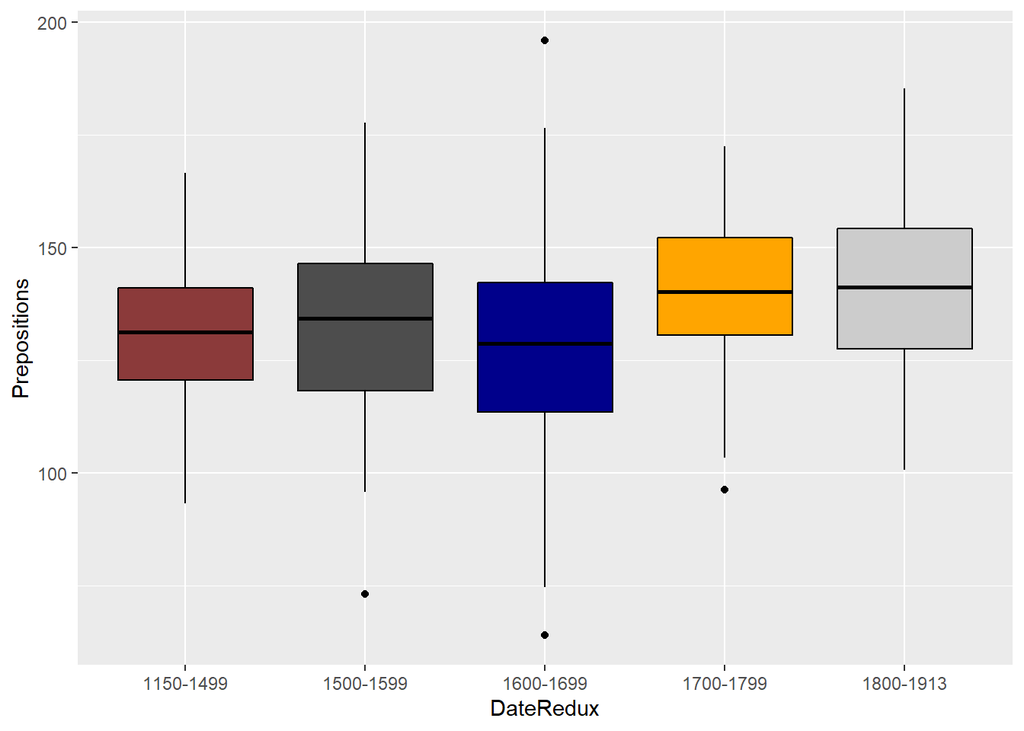

```r
# create boxplot
ggplot(boxdata, aes(DateRedux, Prepositions, color = GenreRedux)) +
  geom_boxplot(fill=mycol,
               color="black")
```

Another interesting feature of boxplots is that they allow us to visually get an idea whether categories differ significantly. Because if add “notch = T” and the notches of the boxplots do not overlap, then this is a very strong indication that the categories actually differ significantly (see below).

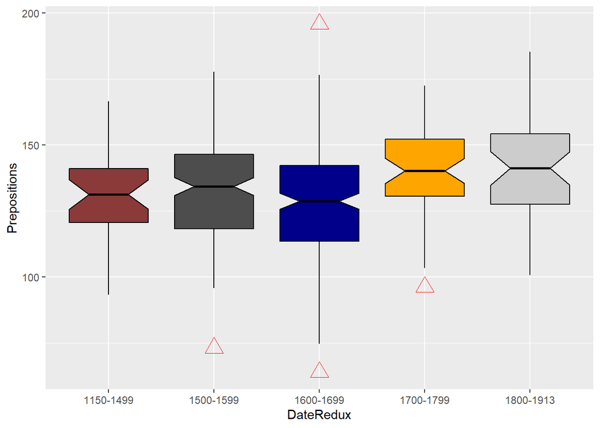

```r
# create boxplot
ggplot(boxdata, aes(DateRedux, Prepositions, color = GenreRedux)) +
  geom_boxplot(outlier.colour="red",
               outlier.shape=2,
               outlier.size=5,
               notch=T,
               fill=mycol,
               color="black")
```

# Word clouds

Word clouds visualize word frequencies of either single corpus or different corpora. Although word clouds are rarely used in academic publications, they are a common way to display language data and the topics of texts - which may be thought of as their semantic content. To exemplify how to use word clouds, we are going to have a look at rally speeches of Hillary Clinton and Donald Trump that were given during their 2016 campaigns. In a first step, we load and process the data as the relevant packages are already loaded.

```r
# load and process speeches by clinton
clinton <- readLines("https://slcladal.github.io/data/Clinton.txt") %>%
  paste(sep = " ", collapse = " ")
# load and process speeches by trump
trump <- readLines("https://slcladal.github.io/data/Trump.txt") %>%
  paste(sep = " ", collapse = " ")
```

After loading the data, we need to clean it.

```r
# clean texts
docs <- Corpus(VectorSource(c(clinton, trump))) %>%
  tm_map(removePunctuation) %>%
  tm_map(removeNumbers) %>%
  tm_map(tolower)  %>%
  tm_map(removeWords, stopwords("english")) %>%
  tm_map(stripWhitespace) %>%
  tm_map(PlainTextDocument)
# create term document matrix
tdm <- TermDocumentMatrix(docs) %>%
  as.matrix()
colnames(tdm) <- c("Clinton","Trump")
```

Next, we normalize the absolute frequencies of the terms in the document by converting them into relative frequencies.

```r
# calculate rel. freq.
tdm[, 1] <- as.vector(unlist(sapply(tdm[, 1], function(x) round(x/colSums(tdm)[1]*1000, 0) )))
# calculate rel. freq.
tdm[, 2] <- as.vector(unlist(sapply(tdm[, 2], function(x) round(x/colSums(tdm)[2]*1000, 0) )))
```

After processing the data, we can now create word clouds. However, there are different word clouds:

- (Common) word clouds
- Comparative clouds
- Commonality clouds

Common or simple word clouds simply show the frequency of word types while comparative word clouds show which word types are particularly overrepresented in one sub-corpus compared to another sub-corpus. Commonality word clouds show words that are shared and are thus particularly indistinctive for different sub-corpora.

Let us first inspect a common word cloud of the corpus.

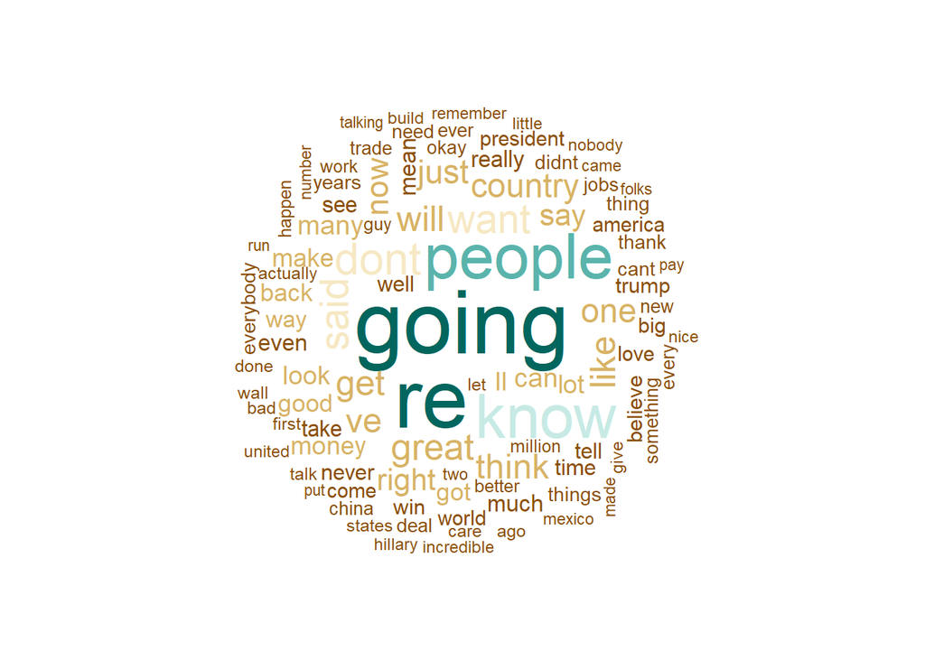

```r
# create word cloud
wordcloud(docs, max.words = 100,
          colors = brewer.pal(6, "BrBG"),
          random.order = FALSE)
```

The common word cloud shows the frequencies of words regardless of who used them. In contrast, the comparative cloud shown below highlights words that differ most with respect to their frequencies in the sub-corpora under investigation.

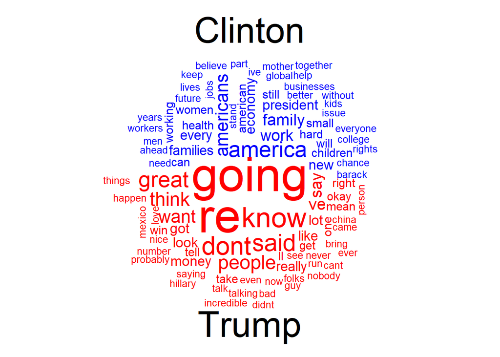

```r
# create comparison cloud
comparison.cloud(tdm,
                 max.words = 100,
                 random.order = FALSE,
                 colors = c("blue", "red"),
                 title.bg.colors="white",
                 bg.color = "black")
```

The opposite of comparative clouds are commonality clouds which highlight words that use with similar relative frequencies in the sub-corpora under investigation and that are therefore particularly indistinctive.

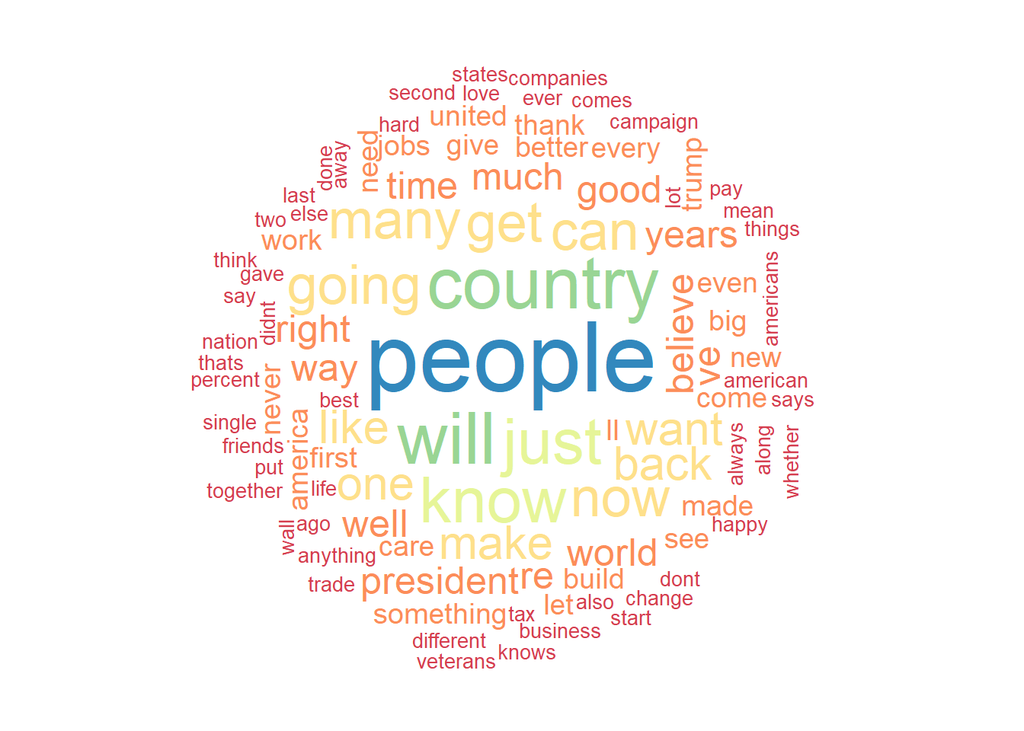

```r
# create commonality cloud
commonality.cloud(tdm,
                  max.words = 100,
                  random.order = FALSE,
          colors = brewer.pal(6, "Spectral"))
```

At first, I thought that word clouds are simply a fancy but not very helpful way to inspect language data but I have to admit that word clouds really surprised me as they do appear to possess potential to provide an idea of what groups of people are talking about. The comparative word cloud shows that the Trump uses a lot of contractions (“’re”, “’ll”, etc.) and stresses concepts linked to the future (*going*) thereby stressing his vision of the US (*great*). In Contrast, Clinton did not use contractions but talked about *Americans*, *work*, the *economy*, and *women*.

# Citation & Session Info

Schweinberger, Martin. 2020. *Basic Data Visualization in R*. Brisbane: The University of Queensland. url: https://slcladal.github.io/basicgraphs.html (Version 2020.12.03).

```
@manual{schweinberger2020adviz,
  author = {Schweinberger, Martin},
  title = {Basic Data Visualization in R},
  note = {https://slcladal.github.io/basicgraphs.html},
  year = {2020},
  organization = {The University of Queensland, School of Languages and Cultures},
  address = {Brisbane},
  edition = {2020/12/03}
}
```

[Main page](https://slcladal.github.io/index.html)

# References

Healy, Kieran. 2018. *Data Visualization: A Practical Introduction*. Princeton University Press.

Wickham, Hadley. 2016. *Ggplot2: Elegant Graphics for Data Analysis*. springer.

Wilkinson, Leland. 2012. “The Grammar of Graphics.” In *Handbook of Computational Statistics. Concepts and Methods*, edited by James E. Gentle, Wolfgang Karl H, and Yuichi Mori, 375–414. Springer.